# Taller 1 - Inteligencia Computacional - Curso 21-22

Nazarie Cerlat, David Carretero, Lluís Bernat

18/10/2021

*a)* La instrucción de R *mvrnom* permite crear una muestra de datos aleatorios que siguen una normal multivariada. Cread tres muestras aleatorias de datos a partir de normales multivariadas con medias $(0,0)$, $(20,20)$ y $(-20,-20)$ y con matriz de covarianzas
$$\left(\begin{matrix} 5 & 2\\2&5 \end{matrix}\right).$$
Representad gráficamente los datos coloreando de un color distinto cada una de las muestras. **[2 puntos]**

```r
library('MASS')
```

```r
sigma <- matrix(c(5,2,2,5),2,2)
m1 = mvrnorm(n=50, Sigma = sigma, mu = c(0, 0))
m2 = mvrnorm(n=50, Sigma = sigma, mu = c(20, 20))
m3 = mvrnorm(n=50, Sigma = sigma, mu = c(-20, -20))
```

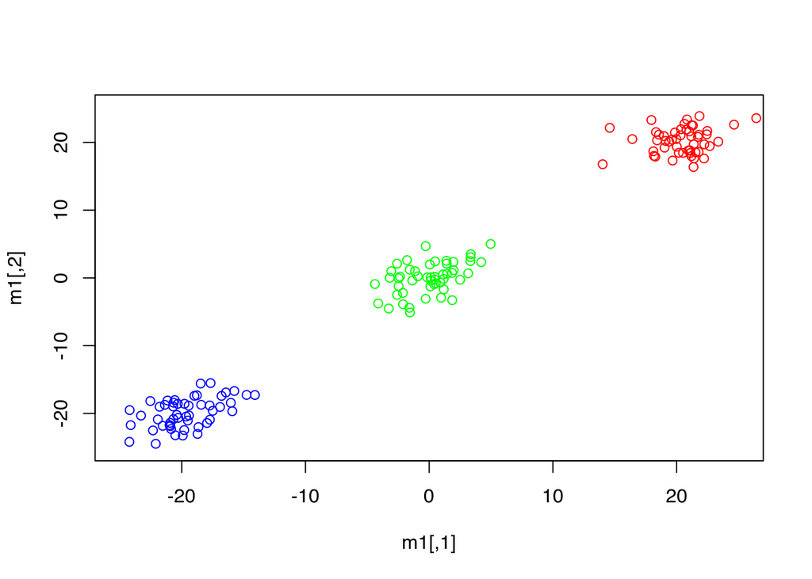

```r
plot(m1, col='green', xlim=c(-25, 25), ylim=c(-25, 25))
points(m2, col='red')
points(m3, col='blue')
```

*b)* Determinad el número óptimo de clústers para los datos anteriores. Justificad la respuesta. **[1.5 puntos]**

```r
df = rbind(m1, m2, m3)
```

```r
library('NbClust')
```

```r
resnumclust<-NbClust(df, distance = "euclidean", min.nc=2, max.nc=4, method = "kmeans", index = "alllong")
```

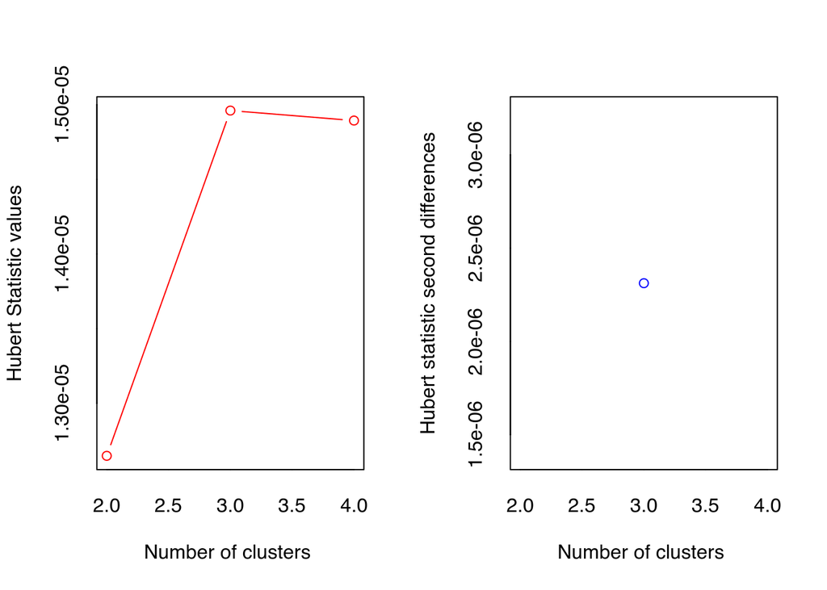

```
## *** : The Hubert index is a graphical method of determining the number of clusters.
##                 In the plot of Hubert index, we seek a significant knee that corresponds to a
##                 significant increase of the value of the measure i.e the significant peak in Hubert
##                 index second differences plot.
##
```

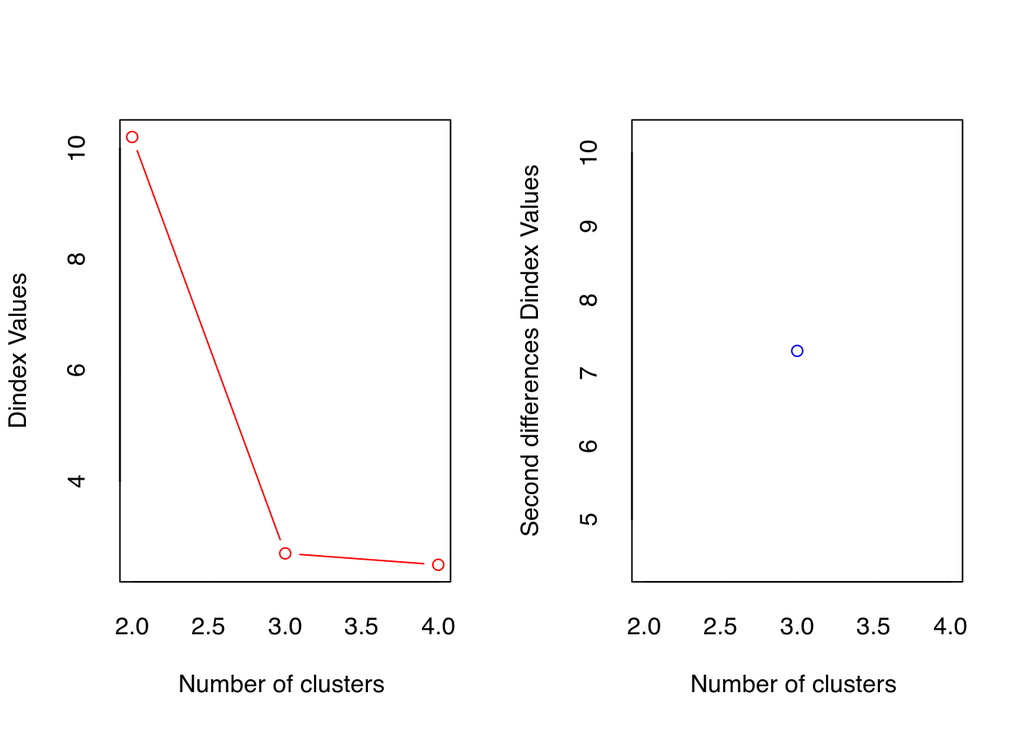

```
## *** : The D index is a graphical method of determining the number of clusters.
##                 In the plot of D index, we seek a significant knee (the significant peak in Dindex
##                 second differences plot) that corresponds to a significant increase of the value of
##                 the measure.
##
## * Among all indices:
## * 1 proposed 2 as the best number of clusters
## * 25 proposed 3 as the best number of clusters
## * 1 proposed 4 as the best number of clusters
##
##                    ***** Conclusion *****
##
## * According to the majority rule, the best number of clusters is  3
##
##
```

```r
resnumclust
```

```
## $All.index
##        KL        CH  Hartigan     CCC    Scott  Marriot   TrCovW    TraceW
## 2  1.0597  429.6283 2025.1815 -0.2766 207.0674 34477228 182466.0 20957.673
## 3 76.4204 4138.6938   28.7832 18.5355 659.7619  3793412 177015.0  1427.279
## 4  0.8110 3286.4619   15.9081 13.8287 699.7668  5165133 177386.8  1193.572
##   Friedman   Rubin Cindex     DB Silhouette   Duda  Pseudot2   Beale Ratkowsky
## 2  73.9780  3.9034 0.3289 0.4024     0.6875 0.0496 1876.2348 18.9519    0.6098
## 3 136.0989 57.3166 0.2673 0.2225     0.8578 0.5415   40.6471  0.8295    0.5723
## 4 149.0375 68.5394 0.2514 0.6197     0.6907 0.7120   19.4182  0.3963    0.4963
##         Ball Ptbiserial     Gap    Frey McClain  Gamma    Gplus      Tau   Dunn
## 2 10478.8363     0.7382 -0.3636  0.5025  0.2583 0.8217 246.2983 2270.267 0.3595
## 3   475.7596     0.8140  1.5613 10.6993  0.2083 1.0000   0.0000 2466.443 1.0488
## 4   298.3931     0.7253  1.1050 18.0654  0.2691 0.9536  51.8294 2130.136 0.0421
##   Hubert SDindex  Dindex   SDbw
## 2      0  0.1724 10.2031 0.5293
## 3      0  0.0947  2.6972 0.0175
## 4      0  0.6494  2.4925 0.3467
##
## $All.CriticalValues
##   CritValue_Duda CritValue_PseudoT2 Fvalue_Beale CritValue_Gap
## 2         0.4349           127.3323       0.0000       -1.9185
## 3         0.3327            96.2763       0.4394        0.4648
## 4         0.3327            96.2763       0.6739        0.2623
##
## $Best.nc
##                      KL       CH Hartigan     CCC    Scott  Marriot   TrCovW
## Number_clusters  3.0000    3.000    3.000  3.0000   3.0000        3    3.000
## Value_Index     76.4204 4138.694 1996.398 18.5355 452.6945 32055537 5451.009
##                   TraceW Friedman    Rubin Cindex     DB Silhouette   Duda
## Number_clusters     3.00   3.0000   3.0000 4.0000 3.0000     3.0000 3.0000
## Value_Index     19296.69  62.1209 -42.1903 0.2514 0.2225     0.8578 0.5415
##                 PseudoT2  Beale Ratkowsky     Ball PtBiserial    Gap Frey
## Number_clusters   3.0000 3.0000    2.0000     3.00      3.000 3.0000    1
## Value_Index      40.6471 0.8295    0.6098 10003.08      0.814 1.5613   NA
##                 McClain Gamma Gplus      Tau   Dunn Hubert SDindex Dindex
## Number_clusters  3.0000     3     3    3.000 3.0000      0  3.0000      0
## Value_Index      0.2083     1     0 2466.443 1.0488      0  0.0947      0
##                   SDbw
## Number_clusters 3.0000
## Value_Index     0.0175
##
## $Best.partition
##   [1] 3 3 3 3 3 3 3 3 3 3 3 3 3 3 3 3 3 3 3 3 3 3 3 3 3 3 3 3 3 3 3 3 3 3 3 3 3
##  [38] 3 3 3 3 3 3 3 3 3 3 3 3 3 1 1 1 1 1 1 1 1 1 1 1 1 1 1 1 1 1 1 1 1 1 1 1 1
##  [75] 1 1 1 1 1 1 1 1 1 1 1 1 1 1 1 1 1 1 1 1 1 1 1 1 1 1 2 2 2 2 2 2 2 2 2 2 2
## [112] 2 2 2 2 2 2 2 2 2 2 2 2 2 2 2 2 2 2 2 2 2 2 2 2 2 2 2 2 2 2 2 2 2 2 2 2 2
## [149] 2 2
```

*c)* Fijando el número de clústers óptimo, realizad un k-means clásico, representando gráficamente el resultado obtenido y calculad el valor de $SS_C$ para este resultado. A continuación, realizad las mismas tareas pero ejecutando la función un número considerable de veces para asegurar un resultado significativo. ¿Existen diferencias entre ambos resultados? ¿Coinciden los centros con las medias de las normales multivariadas escogidas? **[1.5 puntos]**

```r
km <- kmeans(df, centers = 3, nstart = 1)
sum(km$withinss)
```

```
## [1] 1427.279
```

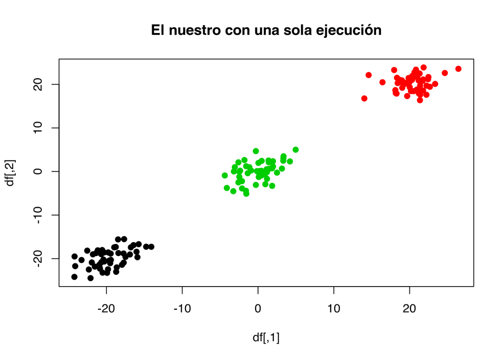

```r
plot(df, col=km$cluster, pch=19, main="El nuestro con una sola ejecución")
```

```r
km2 <- kmeans(df, centers = 3, nstart = 100)
sum(km2$withinss)
```

```
## [1] 1427.279
```

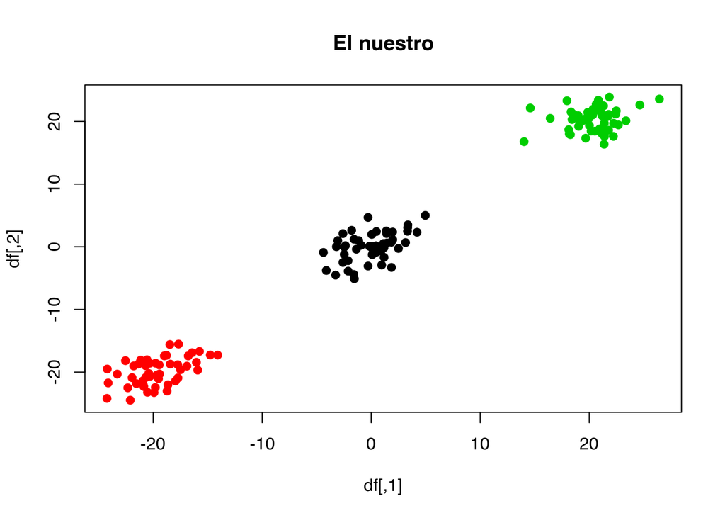

```r
plot(df, col=km2$cluster, pch=19, main="El nuestro")
```

```r
km2
```

```
## K-means clustering with 3 clusters of sizes 50, 50, 50
##
## Cluster means:
##          [,1]          [,2]
## 1  -0.0132396   0.004163916
## 2 -19.6630975 -19.872929498
## 3  20.4071797  20.237720331
##
## Clustering vector:
##   [1] 1 1 1 1 1 1 1 1 1 1 1 1 1 1 1 1 1 1 1 1 1 1 1 1 1 1 1 1 1 1 1 1 1 1 1 1 1
##  [38] 1 1 1 1 1 1 1 1 1 1 1 1 1 3 3 3 3 3 3 3 3 3 3 3 3 3 3 3 3 3 3 3 3 3 3 3 3
##  [75] 3 3 3 3 3 3 3 3 3 3 3 3 3 3 3 3 3 3 3 3 3 3 3 3 3 3 2 2 2 2 2 2 2 2 2 2 2
## [112] 2 2 2 2 2 2 2 2 2 2 2 2 2 2 2 2 2 2 2 2 2 2 2 2 2 2 2 2 2 2 2 2 2 2 2 2 2
## [149] 2 2
##
## Within cluster sum of squares by cluster:
## [1] 509.6890 510.4278 407.1619
##  (between_SS / total_SS =  98.3 %)
##
## Available components:
##
## [1] "cluster"      "centers"      "totss"        "withinss"     "tot.withinss"
## [6] "betweenss"    "size"         "iter"         "ifault"
```

En la segunda ejecución (100 iteraciones), los centros se han ubicado cerca de los originales, con un márgenes del 2%.

*d)* Realizad un fuzzy k-means con valor de fuzzyficador 2 y 3 clústers, ejecutando la función un número considerable de veces para asegurar un resultado significativo. Realizad lo mismo pero ahora con 4 clústers. Determinad usando un criterio cuantitativo y uno gráfico (los que queráis) qué número de clústers es mejor. **[3 puntos]**

```r
library('fclust')
```

```r
fkm3 <- FKM(X=df, k=3, stand = 0, m=2, RS=100)
```

```r
fkm4 <- FKM(X=df, k=4, stand = 0, m=2, RS=100)
```

```r
PE(fkm3$U)
```

```
## [1] 0.09148244
```

```r
PE(fkm4$U)
```

```
## [1] 0.2357005
```

```r
table(fkm3$clus[,1],fkm4$clus[,1])
```

```
##
##      1  2  3  4
##   1 50  0  0  0
##   2  0  0 19 31
##   3  0 50  0  0
```

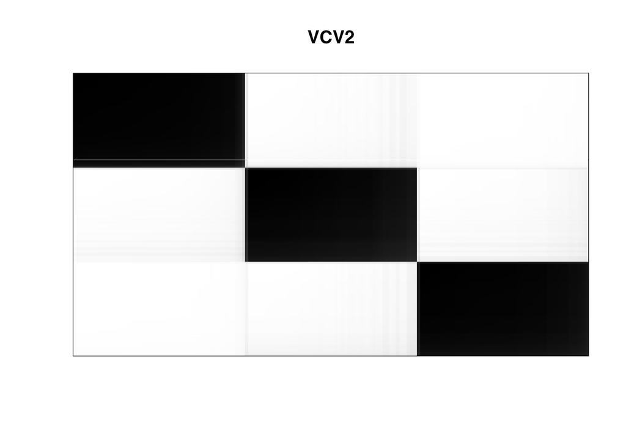

```r
VCV2(fkm3$Xca, fkm3$U, 2)
```

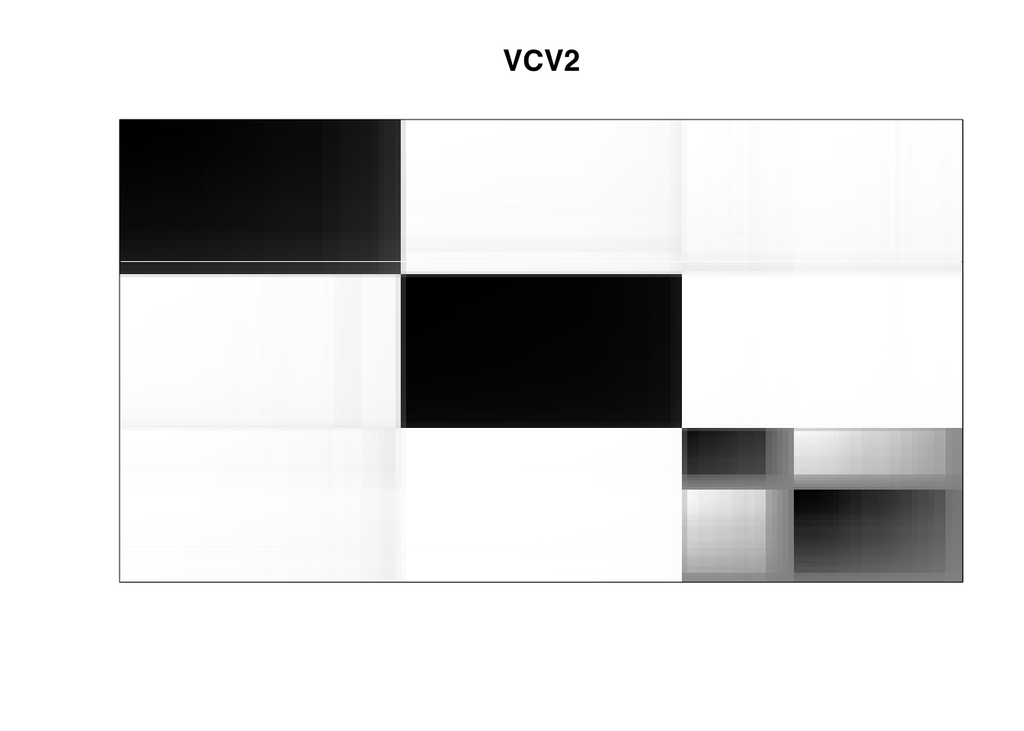

```r
VCV2(fkm4$Xca, fkm4$U, 2)
```

*e)* Añadid una muestra adicional de una normal multivariada con media $(100,100)$ y misma matriz de covarianza. Realizad un fuzzy clustering con 4 clústers, ejecutando un número considerable de veces para asegurar un resultado significativo. ¿Se han movido significativamente los centros obtenidos con 3 clústers del apartado anterior con respecto a los centros obtenidos en este apartado? **[2 puntos]**

```r
m4 <- mvrnorm(n=50, Sigma = sigma, mu = c(100, 100))
```

```r
df2 <- rbind(df, m4)
fkm4b <- FKM(X=df2, k=4, stand = 0, m=2, RS=100)
```

```r
fkm4$H
```

```
##               Var 1        Var 2
## Clus 1  20.43644925  20.23841258
## Clus 2   0.01070894   0.04315802
## Clus 3 -17.55394608 -18.05662707
## Clus 4 -20.99363914 -21.18062726
```

```r
fkm4b$H
```

```
##               Var 1         Var 2
## Clus 1 -19.69292307 -19.891837938
## Clus 2  99.86732048  99.635467909
## Clus 3  -0.01862607   0.006627261
## Clus 4  20.43147940  20.236766055
```